# Introduction to tidyverse. Day 2.

## 6.3 Histogram

It is relatively straightforward to build a histogram with `ggplot2` thanks to the `geom_histogram()` function. Only one numeric variable is needed in the input. Note that a warning message is triggered with this code: we need to take care of the bin width as explained in the next section.

### 6.3.1 A basic one

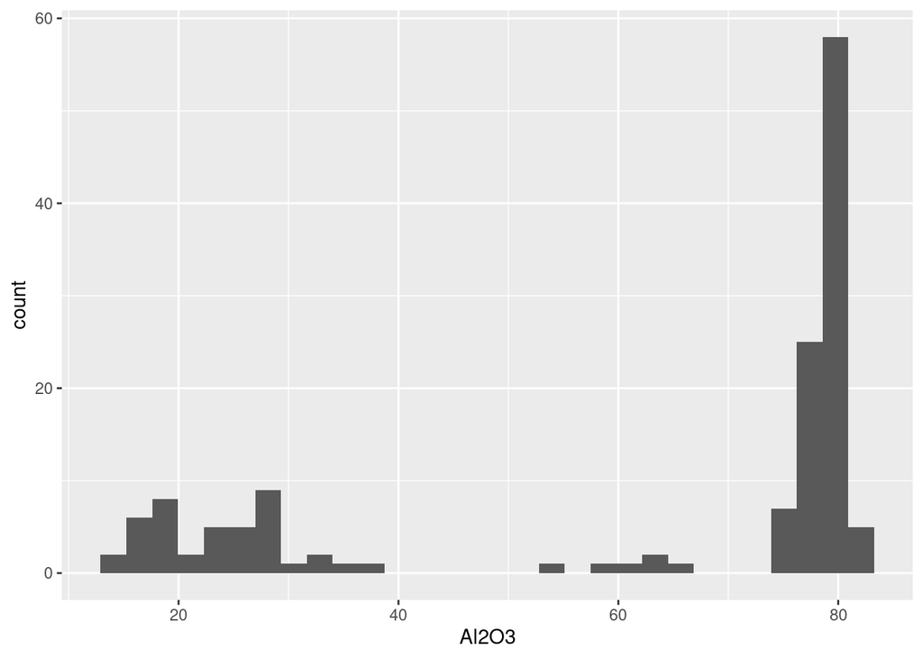

```r
ggplot(data = initial_data_t) +
  geom_histogram(mapping = aes(x = Al2O3))
```

### 6.3.2 The `binwidth` parameter

A histogram takes as input a numeric variable and cuts it into several bins. Playing with the bin size is a very important step, since its value can have a big impact on the histogram appearance and thus on the message you’re trying to convey.

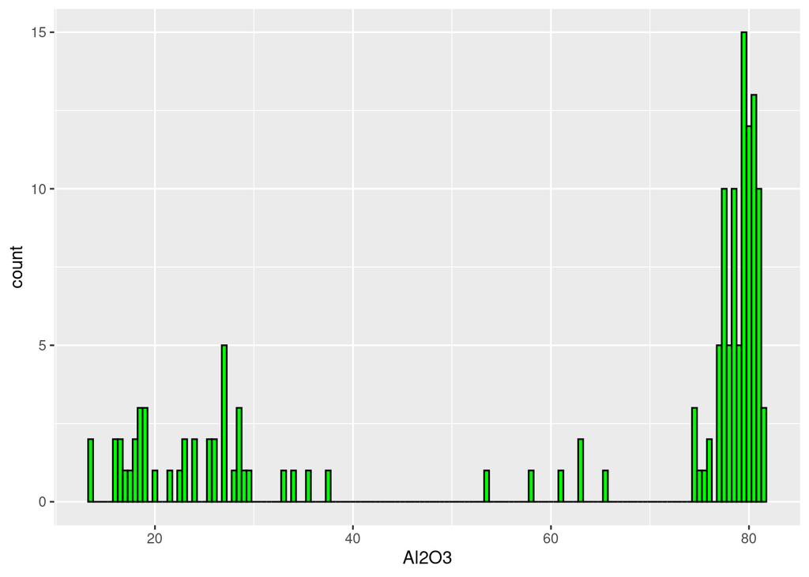

```r
ggplot(data = initial_data_t) +
  geom_histogram(mapping = aes(x = Al2O3), binwidth = 0.5, fill='green', color='black')
```

What happens when you pass >1 as a `binwidth`?

### 6.3.3 Multi histogram

Lets plot two histograms on same plot - BeO with Al2O3.

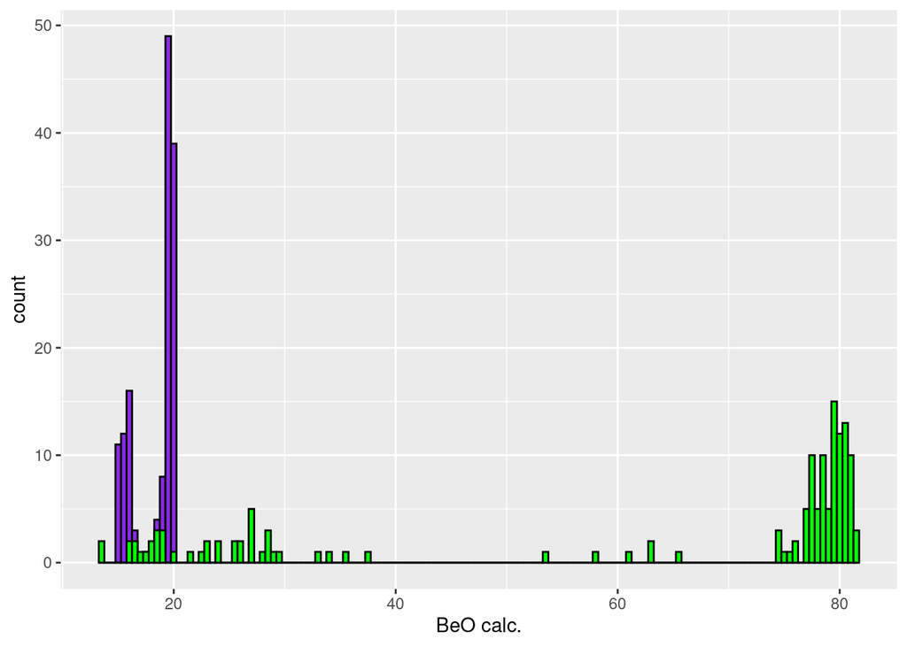

```r
ggplot(data = initial_data_t) +
  geom_histogram(mapping = aes(x = `BeO calc.`), binwidth = 0.5, fill='blueviolet', color='black') +
  geom_histogram(mapping = aes(x = Al2O3), binwidth = 0.5, fill='green', color='black')
```

As you see, the X axis label is a bit misleading.. Lets fix it using `xlab()` method.

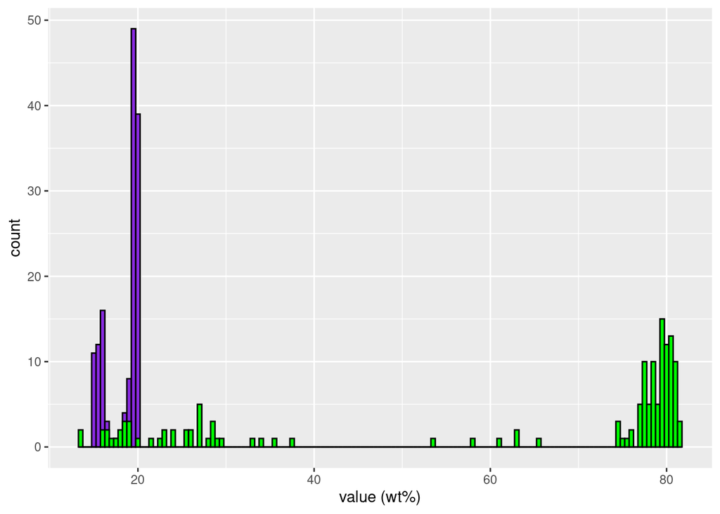

```r
ggplot(data = initial_data_t) +
  geom_histogram(mapping = aes(x = `BeO calc.`), binwidth = 0.5, fill='blueviolet', color='black') +
  geom_histogram(mapping = aes(x = Al2O3), binwidth = 0.5, fill='green', color='black') +
  xlab(label='value (wt%)')
```

# 7 Exercises

## 7.1 Task

Build a binary plot with BeO on X axis and Cr2O3 on the Y axis. Do you see any patterns? Why?

## 7.2 Task

Now, change the color of each observation according to a sample country rock origins. In which rocks the trend is clearly visible? So why we observe that?

## 7.3 Task

Change the color palette using the function `scale_color_brewer()`. Choose a palette you like from [here](https://ggplot2.tidyverse.org/reference/scale_brewer.html#palettes).

## 7.4 Task

Now, change the label of X axis to `BeO (wt%)` and Y axis to `Cr2O3 (wt%)` using the functions `ylab()` and `xlab()`.

## 7.5 Task

Build a density plot. Use `ggplot2` [documentation](https://ggplot2.tidyverse.org/reference/geom_density.html) for doing this. Additionally, you can use [these examples](https://r-graph-gallery.com/135-stacked-density-graph.html).

You will use a new function `geom_density()`. Use the Origin as a group for color, and any variable you wish for calculating densities.

# 8 Congratulations 🙃

You passed the course! Cheers 🍺